# 07 Linear Equations

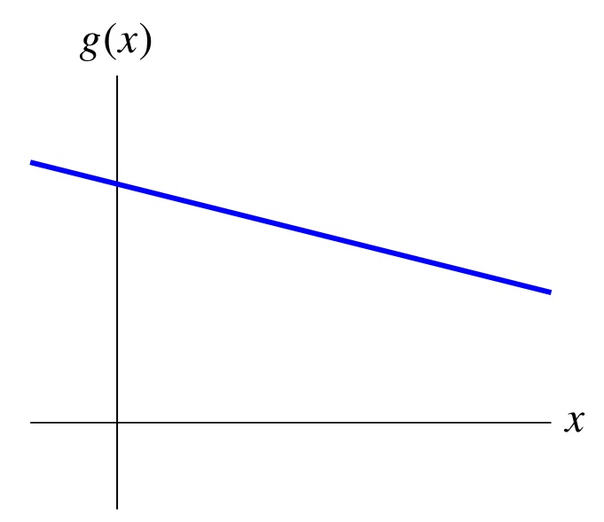

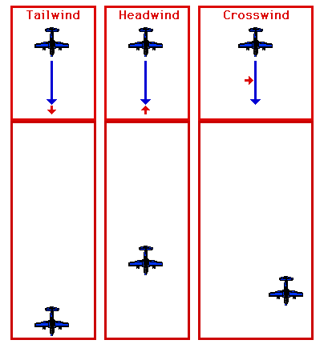

#### Unit 1: Vectors, Book ILA Ch. 1-5

#### Unit 2: Matrices, Book ILA Ch. 6-11 + Book IMC Ch. 2

- 06 Matrices
- *07 Linear Equations*
- 08 Linear Dynamical Systems
- 09 Matrix Multiplication
- 10 Matrix Inverse

#### Unit 3: Least Squares, Book ILA Ch. 12-14 + Book IMC Ch. 8

#### Unit 4: Eigen-decomposition, Book IMC Ch. 10, 12, 19

# Outline: 07 Linear Equations

- **Linear and affine functions**
- Linear equations

# Recall: Superposition and linear functions

$\color{#EF5645}{\text{Notation}}$ (function): The notation $f:\mathbb{R}^n \rightarrow \mathbb{R}$ means $f$ is a function mapping $n$-vectors to numbers. The space $\mathbb{R}^n$ denotes the space of all possible $n$-vectors.

$\color{#EF5645}{\text{Definition}}$ (superposition): We say that the function $f:\mathbb{R}^n \rightarrow \mathbb{R}$ satistifies the superposition property if, for all scalars $\alpha, \beta$ and all $n$-vectors $x, y$:

$$f(\alpha x + \beta y) = \alpha f(x) + \beta f(y)$$

$\color{#EF5645}{\text{Definition}}$ (linear function): A function that satisfies superposition is called linear.

$\color{#6D7D33}{\text{Proposition}}$: A function $f:\mathbb{R}^n \rightarrow \mathbb{R}$ is linear if and only if, for all $n$-vector $x$, $f(x) = a^Tx$ for some $n$-vector $a$.

# Functions $f:\mathbb{R}^n \rightarrow \mathbb{R}^m$

$\color{#EF5645}{\text{Notation}}$: The notation $f:\mathbb{R}^n \rightarrow \mathbb{R}^m$ means $f$ is a function mapping $n$-vectors to $m$-vectors. We write:

- $f(x) = (f_1(x), ..., f_m(x))$ to emphasize components of $f(x)$,
- $f(x) = f(x_1, ..., x_n)$ to emphasize components of $x$,
- $f(x) = (f_1(x_1, ..., x_n), ..., f_m(x_1, ..., x_n))$ to emphasize both.

$\color{#047C91}{\text{Example}}$: Consider the function $f:\mathbb{R}^3 \rightarrow \mathbb{R}^2$ defined as: $f(x_1, x_2, x_3) = (x_2^3 - x_1, -x_3^4),$ which we can also write: $$f\left(\begin{bmatrix} x_1 \\ x_2 \\ x_3\end{bmatrix}\right) = \begin{bmatrix} x_2^3 - x_1 \\ -x_3^4\end{bmatrix}$$

# Superposition and linear functions (General)

$\color{#EF5645}{\text{Definition}}$: We say that the function $f:\mathbb{R}^n \rightarrow \mathbb{R}^m$ satistifies the superposition property if, for all scalars $\alpha, \beta$ and all $n$-vectors $x, y$:

$$f(\alpha x + \beta y) = \alpha f(x) + \beta f(y).$$

$\color{#EF5645}{\text{Definition}}$: A function that satisfies superposition is called linear.

$\color{#6D7D33}{\text{Proposition}}$: A function $f:\mathbb{R}^n \rightarrow \mathbb{R}^m$ is linear if and only if, for all $n$-vector $x$, $f(x) = A x$ for some $m \times n$ matrix $A$.

$\color{#047C91}{\text{Example}}$: The function $f:\mathbb{R}^n \rightarrow \mathbb{R}^{n-1}$ defined by: $$f(x_1, ..., x_n) = (x_2 - x_1, x_3 - x_2, ..., x_n - x_{n-1})$$ is a linear function. It can also be written as: $$f(x) = Dx$$ where $D$ is the difference matrix from the previous lecture.

$\color{#047C91}{\text{Exercise}}$: Consider a function $f:\mathbb{R}^n \rightarrow \mathbb{R}^m$ defined by: $$f\left(\begin{bmatrix} x_1 \\ x_2 \\ x_3\end{bmatrix}\right) = \begin{bmatrix} 5 x_2 - x_1 \\ 2 x_3\end{bmatrix}.$$ What is the matrix $A$ such that: $f(x) = Ax$?

$\color{#047C91}{\text{Exercise}}$: Consider a function $f:\mathbb{R}^n \rightarrow \mathbb{R}^m$, that is linear. What is the matrix $A$ such that: $f(x) = Ax$?

# Recall: Affine functions

$\color{#EF5645}{\text{Definition}}$ (affine function): A function $f:\mathbb{R}^n \rightarrow \mathbb{R}$ that is linear plus a constant is called affine. Its general form is:

$$f(x) = a^Tx+b \quad \text{with $a$ an $n$-vector and $b$ a scalar}$$

$\color{#6D7D33}{\text{Proposition}}$: A function $f:\mathbb{R}^n \rightarrow \mathbb{R}$ is affine if and only if, for all scalars $\alpha, \beta$ with $\alpha + \beta = 1$ and all $n$-vectors $x, y$, we have: $$f(\alpha x + \beta y) = \alpha f(x) + \beta f(y).$$

# Affine functions (General)

$\color{#EF5645}{\text{Definition}}$: A function $f:\mathbb{R}^n \rightarrow \mathbb{R}^m$ that is linear plus a constant is called affine. Its general form is:

$$f(x) = Ax+b \quad \text{with $A$ an $m\times n$ matrix and $b$ a $m$-vector}$$

$\color{#6D7D33}{\text{Proposition}}$: A function $f:\mathbb{R}^n \rightarrow \mathbb{R}^m$ is affine if and only if, for all scalars $\alpha, \beta$ with $\alpha + \beta = 1$ and all $n$-vectors $x, y$, we have: $$f(\alpha x + \beta y) = \alpha f(x) + \beta f(y).$$

$\color{#047C91}{\text{Exercise}}$: Consider an affine function $f:\mathbb{R}^3 \rightarrow \mathbb{R}^2$ defined by: $$f\left(\begin{bmatrix} x_1 \\ x_2 \\ x_3\end{bmatrix}\right) = \begin{bmatrix} 5 x_2 - x_1 + 3\\ 2 x_3 + 2\end{bmatrix}.$$ What is the matrix $A$ and the vector $b$ such that: $f(x) = Ax + b$?

$\color{#047C91}{\text{Exercise}}$: Consider a function $f:\mathbb{R}^n \rightarrow \mathbb{R}^m$, that is affine. What is the matrix $A$ and the vector $b$ such that: $f(x) = Ax + b$?

# Outline: 07 Linear Equations

- Linear and affine functions
- Linear equations

$\color{#EF5645}{\text{Definition}}$: A set (or system) of $m$ linear equations in $n$ variables $x_1, . . . , x_n$ is defined as: $$\begin{matrix} A_{11}x_1 + A_{12}x_2 + · · · + A_{1n}x_n = b_1 \\ A_{21}x_1 + A_{22}x_2 + · · · + A_{2n}x_n = b_2 \\ \vdots \\ A_{m1}x_1 + A_{m2}x_2 + · · · + A_{mn}x_n = b_m \end{matrix}$$ In this system:

- the matrix $A$ and the vector $b$ are given, and the goal is to find $x_1, ..., x_n$.
- n-vector x is called the variable or unknown,
- $A_{ij}$ are the coefficients, $A$ is the coefficient matrix
- b is called the right-hand side

$\color{#EF5645}{\text{Remark}}$: A system of linear equations can be expressed very compactly as $Ax = b$.

$\color{#EF5645}{\text{Definition}}$: A system of linear equations is called:

- under-determined if $m < n$ ($A$ wide)
- square if $m = n$ ($A$ square)
- over-determined if $m > n$ ($A$ tall)

$\color{#EF5645}{\text{Definition}}$: If we find a vector $x$ such that $Ax = b$, then $x$ is called a solution of the system of equations.

$\color{#EF5645}{\text{Definition}}$: Depending on $A$ and $b$, there can be:

- many solutions
- one solution
- no solution

$\color{#047C91}{\text{Exercise}}$: An airplane travels 1200 miles in 4 hours with a tail wind. On the way back, the same trip takes 5 hours, now with a head wind (against the wind). What is the speed of the plane in still air, and what was the wind speed?

$\color{#EF5645}{\text{Remark}}$: We will see later (after learning a bit more on operations on matrices) how to automatically solve such a system.

# Outline: 07 Linear Equations

- Linear and affine functions
- Linear equations

Resources: Ch. 8 of ILA